# Week 9 Exercises

February 13, 2019

# Lab This Week

You have to individually:

- join datasets
- work with and manipulate strings
- work with and manipulate factors
- work with and manipulate dates and times

Let’s make sure we have a handle on all of these skills.

## Joining Data

Sometimes our data is in two separate data frames, and we want to combine them into one. There are four diffferent ways to join data.

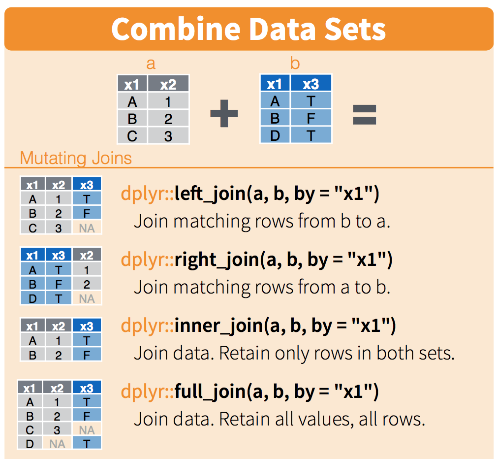

**Exercise**: Let’s practice an example with full_join. If you were to use left_join, how many rows would there be in our new data frame? Check your answer.

```r
# Generate tibbles to work with
x <- tribble(
  ~key, ~val_x,
     1, "x1",
     2, "x2",
     3, "x3"
)
y <- tribble(
  ~key, ~val_y,
     1, "y1",
     2, "y2",
     4, "y3"
)

# Join the data frams
xy <- x %>%
  full_join(y, by = "key")
```

## Strings

A large chunk of data science involves Natural Language Processing, so it’s beneficial to know how to work with strings. For the data science applications that we cover in this class, we don’t work with strings too often. However, knowing the basics is extremely helpful when you do have to use it.

```r
# Generate strings
str1 <- "This is my string"
str2 <- "Puppies"
str3 <- "Kitties"
strVec <- x <- c("Ramthorn", NA)

# Length of string
str_count(str1)
```

```
## [1] 17
```

```r
length(str1) # What does this do?
```

```
## [1] 1
```

```r
# Combining strings
str_combined <- str_c(str2, str3, sep = ", ")

# Dealing with NAs
str_c(strVec)[2] # Recognized as NA data type
```

```
## [1] NA
```

```r
str_c(str_replace_na(strVec))[2] # Convert NA to string
```

```
## [1] "NA"
```

```r
# Subsetting strings
str_sub(str1, 1, 4)
```

```
## [1] "This"
```

```r
str_sub(str1, -6, -1)
```

```
## [1] "string"
```

## Factors

You have been working with factors all along. These are categorical variables (sometimes I call them group variables). Factors are made up of two parts: a value and a level (group).

```r
# Generate string vector
x <- c("Dec", "Apr", "Jan", "Mar")

# Convert to factor
xFact <- factor(x)
xFact
```

```
## [1] Dec Apr Jan Mar
## Levels: Apr Dec Jan Mar
```

```r
# Add a new month
# What the heck happened?
xFact <- c(xFact, "Feb") # Don't do this
xFact # Bad
```

```
## [1] "2"   "1"   "3"   "4"   "Feb"
```

```r
# Add a new month
xFact[5] <- "Feb"
xFact # Bad
```

```
## [1] "2"   "1"   "3"   "4"   "Feb"
```

```r
# Construct month levels
month_levels <- c(
  "Jan", "Feb", "Mar", "Apr", "May", "Jun",
  "Jul", "Aug", "Sep", "Oct", "Nov", "Dec")

# Convert to factor
xFact2 <- factor(x, levels = month_levels)
xFact2[5] <- "Feb"
xFact2 # Good
```

```
## [1] Dec Apr Jan Mar Feb
## Levels: Jan Feb Mar Apr May Jun Jul Aug Sep Oct Nov Dec
```

## Dates and Times

If you don’t have the correct tools, working with dates and times can be quite the headache. Luckily, R has a package called “lubridate” that makes working with dates and times much easier. [Here](https://cran.r-project.org/web/packages/lubridate/lubridate.pdf) is a link to the CRAN page.

```r
# Load lubridate library
library(lubridate)

# Generate sample dates
date1 <- as.Date("07/13/1994", format = "%m/%d/%Y")
date2 <- as.factor("07/13/1994 1:31")
date3 <- "1994-05-02 5:30AM"

# Extract components of dates
year(date1)
```

```
## [1] 1994
```

```r
day(date1)
```

```
## [1] 13
```

```r
month(date1)
```

```
## [1] 7
```

```r
# Parse the dates
date2 <- mdy_hm(date2)
date3 <- ymd_hm(date3)

# Can we parse this date?
# Format: "mmddyyyyHHMM"
date4 <- "071319940130"
```

**Have some fun with the lab this week!**